# 20220331回家作業

### **1.試找一檔股票**

我選擇了宏達電，因為禮拜四的演講，講師說「xx電元宇宙概念股割完韭菜就跑」，不曉得他是不是在唬爛？所以選擇這檔股票試驗。

### **2.決定進場點**

由於我第一次了解股票，沒有太多經驗（純小白），所以參考老師的買入方式進行試驗。

規則：當今天開盤價高於5日均線時，買入；

（因為台灣證券交易所提供的資料最小單位好像只有日線，所以我買入的標準以當天開盤價為主）

### **3.設定出場點**

規則：（停利：15%）（停損：-8%）

### **4.計算(估計)過去一段時間(1~年)的勝率、宽際賺賠**

| 交易時間 | 110/01/12日至111/02/25 |
| --- | --- |
| **交易次數** | **17次（贏了8次 ; 輸了9次）** |
| **交易勝率** | 0.47 |
| 資料擷取及模擬過程 | 因為兩年的資料很多，而我又懶= =，根本不想要一個個點擊。 所以透過colab使用python抓取個股的交易資訊，同時計算相關資訊。 |
| 程式碼連結 | https://colab.research.google.com/drive/1DdOS3LKNpq71htndAZFp6qhyoWQDK_nE?usp=sharing |
| 資料來源 | 台灣證券交易所—個股日成交資訊（https://www.twse.com.tw/zh/page/trading/exchange/STOCK_DAY.html） |

**下圖是模擬買賣的實際賺賠**

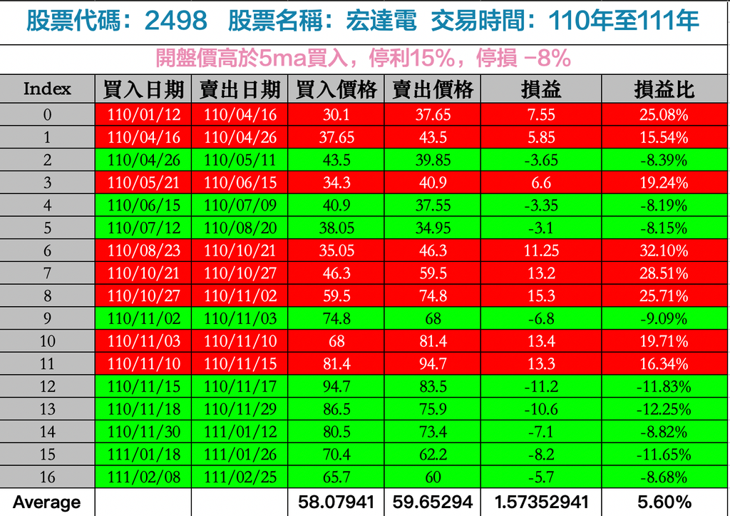

### 5.績效分析

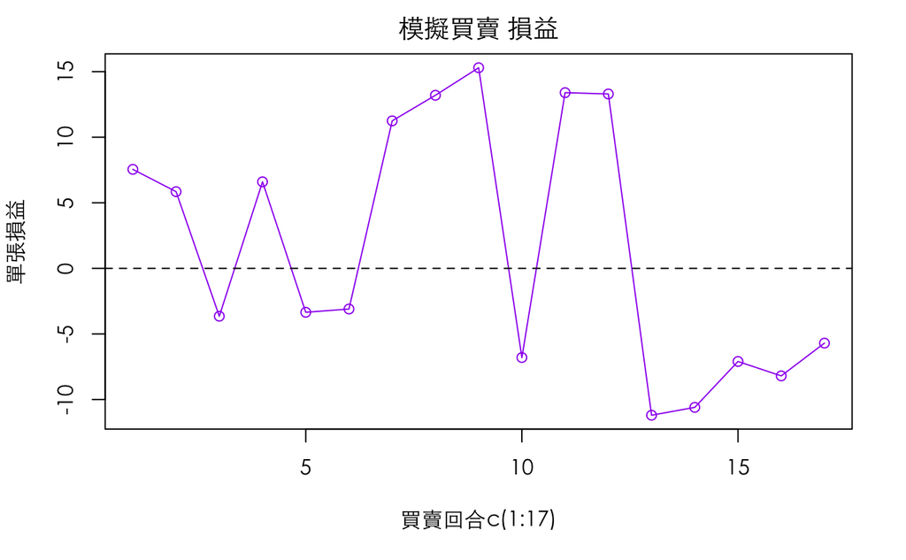

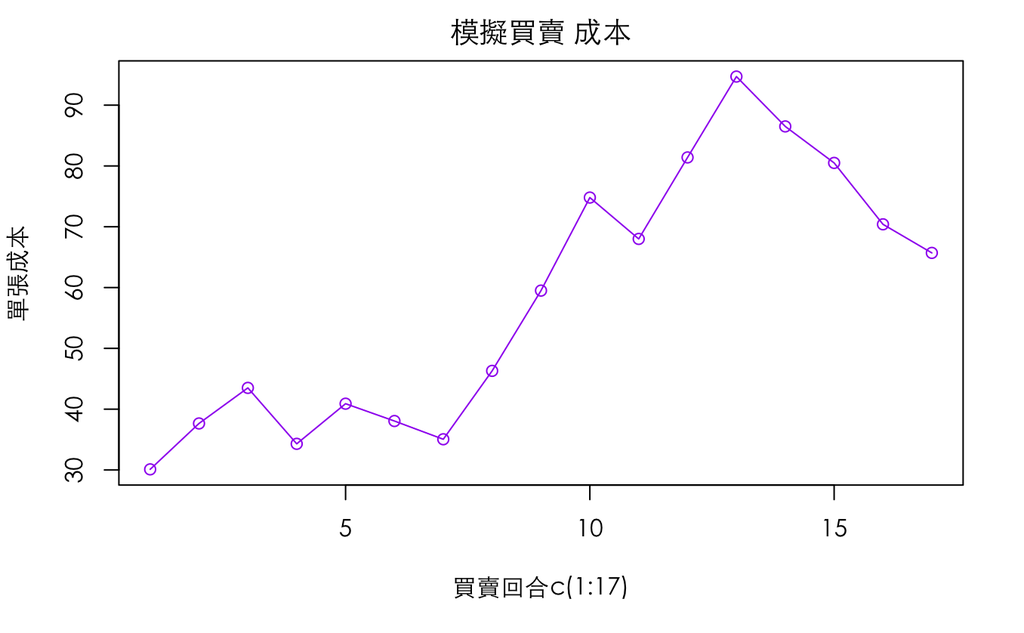

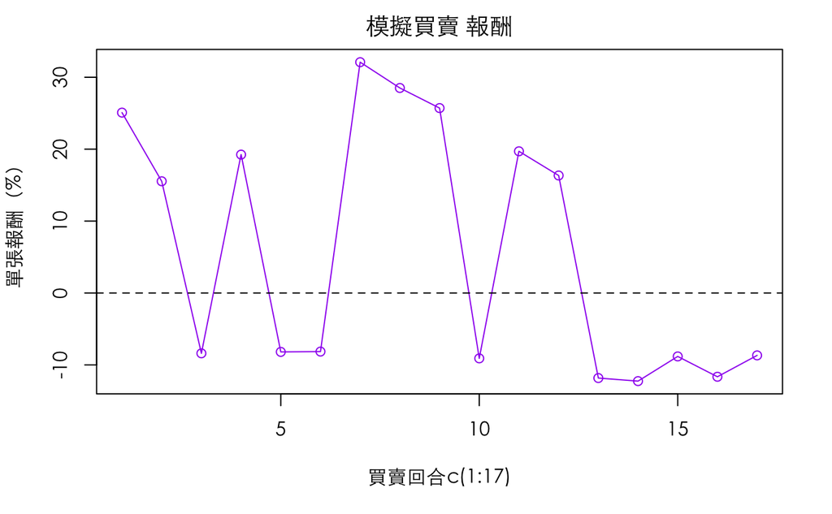

### 根據本次試驗的數據，假設勝率為47%，輸8%，賺15%，則凱利比例為2.34（=234%）

```r
#凱利比例
p=0.47
kelly=(p*0.15+(1-p)*(-0.08))/(0.15*0.08)
print(kelly)
```

```
[1] 2.341667
```

### 假設初始資金為1，損益報酬為PLR=cumprod(1+2.34*ret)

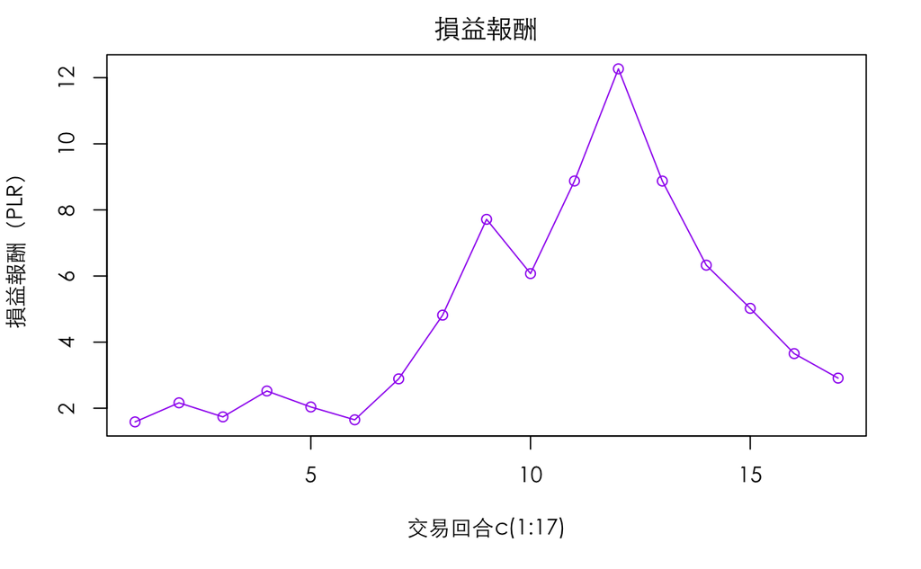

### 不同勝率預估下，凱利賭徒的累計損益

### 停利15%、停損8%，勝率需＞34.7%則有利可圖

- 勝率 35% => Kelly 4.16%
- 勝率 40% => Kelly 100%
- 勝率 45% => Kelly 196%
- 勝率 50% => Kelly 292%
- 勝率 55% => Kelly 387%

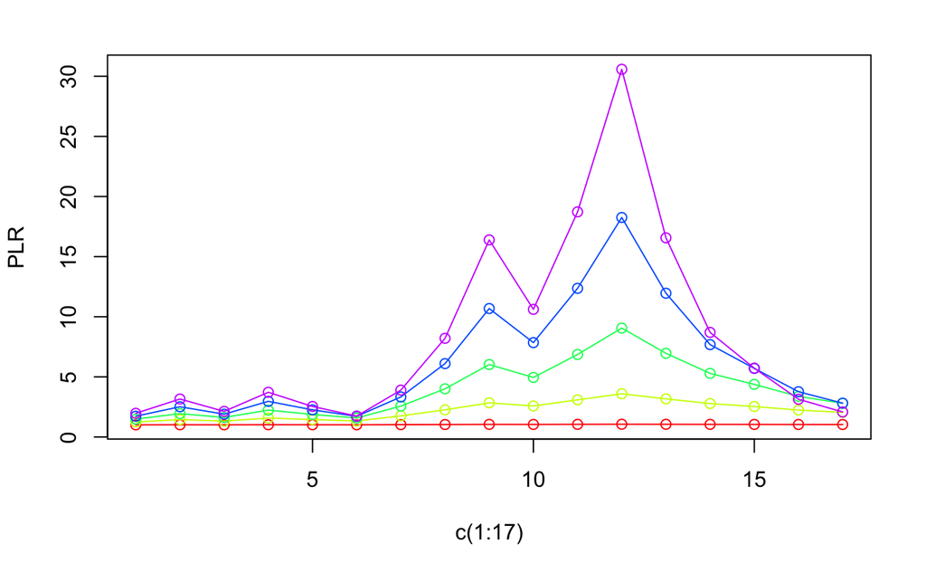

### 6.感想

從實際賺賠的結果來看，第六次漲幅高達32.10%，說明了風口概念股確實很給力。

其次，在一陣高漲之後迎來了連續的下跌，從110年11月起買賣該股連續輸了五次！但得益於停損機制的存在，使得持有股票的成本會相對降低，而不會造成大幅的虧損。

在停利/停損的設定上，我嘗試過使用不同比例，發現如果停損停利設定的小的話，交易次數會增多，賺的反而卻非常少。而如果藝高人膽大，將停損停利幅度調高，交易次數變少，收益卻增長很多！

最後，確實存在割韭菜的嫌疑。